# SPPH 504 Section 007 Lab (10.3) Mediation analysis (3 category mediator) on the CCHS analytic dataset

Ehsan Karim, ehsan.karim@ubc.ca

01 May 2020

Abstract

This is a short instruction document of how to perform mediation analysis (where there is a 3 category mediator) on CCHS dataset.

# 1 Pre-processing

## 1.1 Load saved data

```r
load("OACVDmediate-part1.RData")
```

# 2 Mediator with three categories

Consider a scenario where Physical activity with categories

1. active,
2. moderate and
3. inactive

is hypothesized to be acting as a mediator beyween OA and CVD.

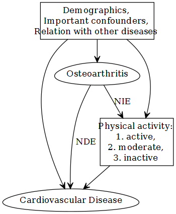

```r
table(analytic2$phyact)
```

```
##
##   Active Inactive Moderate
##     5502    10495     5626
```

```r
analytic2$phyact <- ifelse(analytic2$phyact == "Active", 2,
                            ifelse(analytic2$phyact ==
                                     "Moderate", 1, 0))
analytic2$phyact <- as.ordered(analytic2$phyact)
table(analytic2$phyact)
```

```
##
##     0     1     2
## 10495  5626  5502
```

```r
analytic2$mediator <- analytic2$phyact # new mediator
head(analytic2$mediator) # first few values
```

```
## [1] 1 2 2 0 2 1
## Levels: 0 < 1 < 2
```

# 3 Proportional odds ordinal regression (Mediator model)

The only change compared to the previous part of the lab is that, now we are using a Proportional odds ordinal regression to fit the mediator model (instead of a logistic regression model).

```r
require(VGAM)
m.fit2 <- vglm(mediator ~ exposure  + age + sex +
                   income + race + bmicat +
                   smoke + fruit + ht +
                   copd + diab + edu,
              family=propodds(),
              weight=weight,
              data=analytic2)
exp(coef(m.fit2))["exposure"]
```

```
##  exposure
## 0.9937224
```

```r
confint(m.fit2)
```

```
##                              2.5 %        97.5 %
## (Intercept):1          -1.62558775 -1.608239e+00
## (Intercept):2          -2.80948997 -2.791718e+00
## exposure               -0.01251051 -8.426671e-05
## age40-49 years         -0.09986640 -9.189167e-02
## age50-59 years         -0.16626931 -1.569379e-01
## age60-64 years          0.07833803  9.250254e-02
## sexMale                 0.23182915  2.387877e-01
## income$30,000-$49,999  -0.05593941 -4.394859e-02
## income$50,000-$79,999   0.04472206  5.563569e-02
## income$80,000 or more   0.21873531  2.296229e-01
## raceWhite               0.68388367  6.932754e-01
## bmicatOverweight       -0.26317170 -2.561267e-01
## bmicatUnderweight      -0.19993184 -1.836828e-01
## smokeFormer smoker      0.38012484  3.888510e-01
## smokeNever smoker       0.17818065  1.874802e-01
## fruit4-6 daily serving  0.39610882  4.045570e-01
## fruit6+ daily serving   0.90799828  9.177968e-01
## htYes                  -0.17189420 -1.605386e-01
## copdYes                -0.72624755 -6.748181e-01
## diabYes                 0.01798069  3.659086e-02
## edu2nd grad.            0.19425606  2.067535e-01
## eduOther 2nd grad.      0.25899978  2.755912e-01
## eduPost-2nd grad.       0.42980099  4.410762e-01
```

Rest of the steps are exactly the same as outlined in the previous lab part.

# 4 Obtaining results fast

Compared to the binary mediator case, the only part that changes here is the use of `vglm` instead of `svyglm`. The function `vglm` can handle weights (we use scaled weights).

```r
# doEffectDecomp3 is a user-written function
# See appendix for the function
res <- round(doEffectDecomp3(analytic2, ind = NULL),2)
res
```

```
##   TE   DE   IE   PM
## 1.44 1.44 1.00 0.00
```

The proportion mediated through physical activity was about 0% on the log odds ratio scale!

# 5 Visualization for 3 category mediator

```r
require(boot)
set.seed(127)
bootres3c <- boot(data=analytic2, statistic=doEffectDecomp3,
                R = 10, parallel = "multicore", ncpus=20)
```

R = 10 is not reliable for bootstrap. In real applications, try 250.

```r
bootci1c <- boot.ci(bootres3c,type = "perc",index=1)
bootci2c <- boot.ci(bootres3c,type = "perc",index=2)
bootci3c <- boot.ci(bootres3c,type = "perc",index=3)
bootci4c <- boot.ci(bootres3c,type = "perc",index=4)
bootres3c$R
```

```
## [1] 10
```

```r
TEc <- c(bootres3c$t0[1], bootci1c$percent[4:5])
DEc <- c(bootres3c$t0[2], bootci2c$percent[4:5])
IEc <- c(bootres3c$t0[3], bootci3c$percent[4:5])
mat<- rbind(TEc,DEc,IEc)
colnames(mat) <- c("Point", "2.5%", "97.5%")
mat
```

```
##        Point      2.5%    97.5%
## TEc 1.435424 1.0670560 1.579991
## DEc 1.435407 1.0672140 1.579730
## IEc 1.000012 0.9997903 1.000165
```

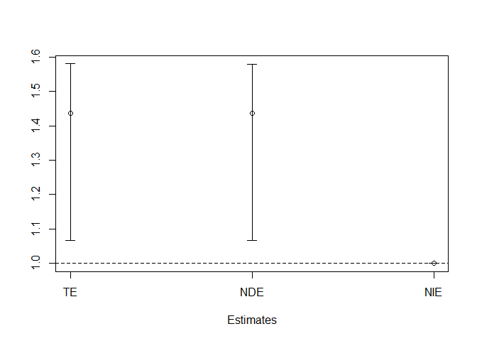

```r
plotCI(1:3, mat[,1], ui=mat[,3], li=mat[,2],
       xlab = "Estimates", ylab = "", xaxt="n")
axis(1, at=1:3,labels=c("TE","NDE","NIE"))
abline(h=1, lty = 2)
```

# 6 Appendix: OC-CVD Functions for bootstrap

This function is written basically for performing bootstrap for the OA-CVD analysis, for mediator with 3 categories. However, changing the covariates names/model-specifications should not be too hard, once you understand the 4 basic steps.

```r
# without interactions (mediator with 3 categories)
doEffectDecomp3
```

```
## function(dat, ind = NULL)
## {
##   #############################################
##   # This function is a modified version of
##   # Rochon, J., du Bois, A., & Lange, T. (2014).
##   # Mediation analysis of the relationship between
##   # institutional research activity and patient survival.
##   # BMC medical research methodology, 14(1), 9.
##   #############################################
##   # Comments at ehsan.karim@ubc.ca
##   #############################################
##   # Step 0: Replicate exposure variable, predict mediators
##   if (is.null(ind)) ind <- 1:nrow(dat)
##   d <- dat[ind,]
##   # d <- analytic2
##   d$exposureTemp <- d$exposure
##   # scaled survey weights
##   d$S.w <- with(d,(weight)/mean(weight))
##   require(VGAM)
##   fit.m <- vglm(mediator ~ exposureTemp  +
##                    age + sex + income + race + bmicat +
##                    smoke + fruit + ht + copd + diab + edu,
##                  family=propodds(),
##                  weight=S.w,
##                  data=d)
##   # summary(fit.m)
##
##   # Steps 1 and 2: Replicate data with different exposures for mediator
##   d1 <- d2 <- d
##   d1$exposure.counterfactual <- 1
##   d2$exposure.counterfactual <- 0
##   newd <- rbind(d1, d2)
##
##   # Step 3: Compute weights for the mediation
##   newd$exposureTemp <- newd$exposure
##   direct <- predict(fit.m, newdata=newd, type='response')[cbind(1:nrow(newd), newd$mediator)]
##   newd$exposureTemp <- newd$exposure.counterfactual
##   indirect <- predict(fit.m, newdata=newd, type='response')[cbind(1:nrow(newd), newd$mediator)]
##   newd$W.mediator <- indirect/direct
##   summary(newd$W.mediator)
```

[output cut: 10 more lines]

```
##                   age + sex + income + race + bmicat + edu +
##                   phyact + smoke + fruit + ht + copd + diab,
##                 design = w.design,
##                 family = quasibinomial("logit"))
##
##   # Return value: Estimates for total, direct, indirect effects
##   TE <- exp(sum(coef(fit)[c('exposure', 'exposure.counterfactual')]))
##   DE <- exp(unname(coef(fit)['exposure']))
##   IE <- exp(unname(coef(fit)[c('exposure.counterfactual')]))
##   PM <- log(IE) / log(TE)
##
##   return(c(TE=TE, DE=DE, IE=IE, PM=PM))
## }
## <bytecode: 0x000000001fb48b30>
## <environment: 0x000000000f2869e8>
```